# 01 - Parallel Slopes

| case | bwt | gestation | parity | age | height | weight | smoke |
| --- | --- | --- | --- | --- | --- | --- | --- |
| 1 | 120 | 284 | 0 | 27 | 62 | 100 | 0 |
| 2 | 113 | 282 | 0 | 33 | 64 | 135 | 0 |
| 3 | 128 | 279 | 0 | 28 | 64 | 115 | 1 |
| 4 | 123 | NA | 0 | 36 | 69 | 190 | 0 |
| 5 | 108 | 282 | 0 | 23 | 67 | 125 | 1 |
| 6 | 136 | 286 | 0 | 25 | 62 | 93 | 0 |
| 7 | 138 | 244 | 0 | 33 | 62 | 178 | 0 |
| 8 | 132 | 245 | 0 | 23 | 65 | 140 | 0 |
| 9 | 120 | 289 | 0 | 25 | 62 | 125 | 0 |
| 10 | 143 | 299 | 0 | 30 | 66 | 136 | 1 |

[output cut: 990 more lines]

## **What if you have two groups?**

**1. Multiple and logistic regression**

Hi, my name is Ben Baumer. I’m an assistant professor of statistical and data sciences at Smith College, and I’ll be your instructor for this course on multiple and logistic regression. In this course, we will learn how to extend simple linear regression to an arbitrary number of explanatory variables, which can be a mixture of numeric and categorical. We’ll also learn about logistic regression, which allows us to model a binary response variable.

**2. Fuel efficiency by engine size**

OK, let’s consider a situation in which simple linear regression might not be sophisticated enough to suit our needs. This scatterplot shows the relationship between highway fuel economy and engine size for 77 configurations of manual transmission cars popular from 1999 to 2008. It appears as though there is a negative relationship between engine size and fuel economy—which should make sense: bigger engines tend to go in bigger cars, which tend to be heavier, and which tend to get worse mileage. We could certainly fit a linear regression line through these points, but that would only tell us part of the story.

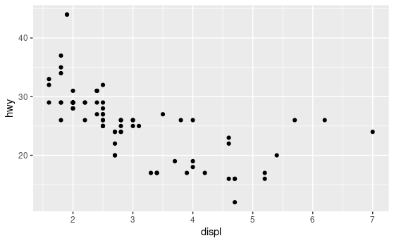

```r
ggplot(data = mpg_manual, aes(x = displ, y = hwy)) +
  geom_point()
```

**3. Fuel efficiency over time**

The truth is that while these cars were popular in each of the ten years between 1999 and 2008, the observations we have are only from 1999 or 2008. Did fuel economy improve over time? These side-by-side boxplots suggest that it might have, but does that represent a feat of engineering? Or merely a change in consumer taste? How do we know that the increase in fuel economy was not just due to the cars in 2008 generally having smaller engines—which we’ve already observed to be associated with greater fuel economy?

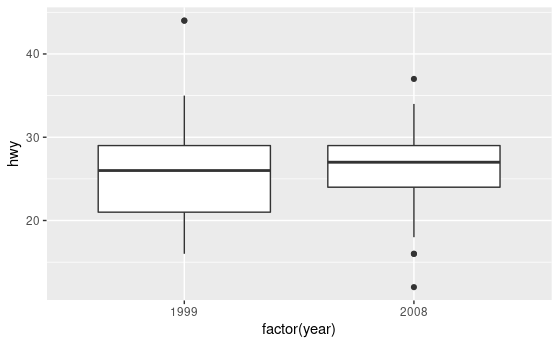

```r
ggplot(data = mpg_manual, aes(x = factor(year), y = hwy)) +
  geom_boxplot()
```

**4. A parallel slopes model**

What we really want is a model that will assess the effects of engine size and year simultaneously. That is, we want to understand the effect of time on fuel economy, after controlling for engine size. Here we see a visual depiction of a parallel slopes model. These models occur when one of the explanatory variables is numeric, and the other is categorical. In this case, the year variables has two levels, and the model accordingly consists of two parallel lines.

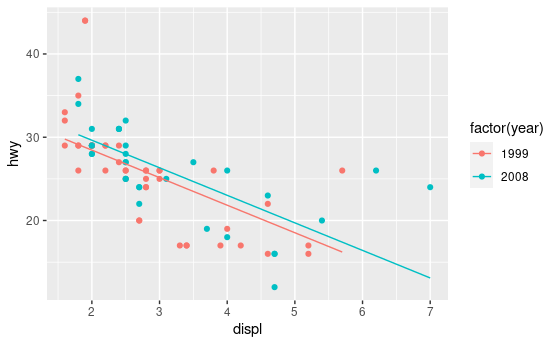

**5. Adding a new variable**

Multiple regression allows us to build such models by simply adding another variable—and another coefficient—to our model.

**6. Adding a new variable in R**

As you might suspect, telling R about the second variable in our regression model is just as easy. We simply add another term to the right-hand-side of the formula that we pass to the lm() function. Here, we have to be a bit careful to make sure that R interprets our year variable as a categorical variable, since it is encoded as a number. For our purposes, the year should be thought of as a label, not a quantity.

```r
lm(hwy ~ dsipl + factor(year), data = mpg)
```

**7. Let’s practice!**

You’ll get some practice working with this in the next set of exercises. Then we’ll move on to visualize these models.

### **Fitting a parallel slopes model**

We use the `lm()` function to fit linear models to data. In this case, we want to understand how the price of MarioKart games sold at auction varies as a function of not only the number of wheels included in the package, but also whether the item is new or used. Obviously, it is expected that you might have to pay a premium to buy these new. But how much is that premium? Can we estimate its value *after controlling for the number of wheels?*

We will fit a parallel slopes model using `lm()`. In addition to the data argument, `lm()` needs to know which variables you want to include in your regression model, and how you want to include them. It accomplishes this using a `formula` argument. A simple linear regression formula looks like `y ~ x`, where `y` is the name of the response variable, and `x` is the name of the explanatory variable. Here, we will simply extend this formula to include multiple explanatory variables. A parallel slopes model has the form `y ~ x + z`, where `z` is a categorical explanatory variable, and `x` is a numerical explanatory variable.

The output from `lm()` is a model object, which when printed, will show the fitted coefficients.

**Instructions**

- The dataset `mario_kart` is already loaded for you. Explore the data using `glimpse()` or `str()`.
- Use `lm()` to fit a parallel slopes model for total price as a function of the number of wheels and the condition of the item. Use the argument `data` to specify the dataset you’re using.

```r
# Explore the data
glimpse(mario_kart)
```

```
Rows: 141
Columns: 12
$ ID         <dbl> 150377422259, 260483376854, 320432…
$ duration   <int> 3, 7, 3, 3, 1, 3, 1, 1, 3, 7, 1, 1…
$ nBids      <int> 20, 13, 16, 18, 20, 19, 13, 15, 29…
$ cond       <fct> new, used, new, new, new, new, use…
$ startPr    <dbl> 0.99, 0.99, 0.99, 0.99, 0.01, 0.99…
$ shipPr     <dbl> 4.00, 3.99, 3.50, 0.00, 0.00, 4.00…
$ totalPr    <dbl> 51.55, 37.04, 45.50, 44.00, 71.00,…
$ shipSp     <fct> standard, firstClass, firstClass, …
$ sellerRate <int> 1580, 365, 998, 7, 820, 270144, 72…
$ stockPhoto <fct> yes, yes, no, yes, yes, yes, yes, …
$ wheels     <int> 1, 1, 1, 1, 2, 0, 0, 2, 1, 1, 2, 2…
$ title      <fct> "~~ Wii MARIO KART &amp; WHEEL ~ N…
```

```r
# fit parallel slopes
mod <- lm(totalPr ~ wheels + cond, data = mario_kart)
mod
```

```
Call:
lm(formula = totalPr ~ wheels + cond, data = mario_kart)

Coefficients:
(Intercept)       wheels     condused
     42.370        7.233       -5.585
```

On average, how much more does a new game cost compared to a used game?

## **Vizualizing parallel slopes models**

**1. Visualizing parallel slopes models**

**2. Three variables, one plot**

In this scatterplot, we use color to differentiate the cars from 2008 from those in 1999. Do you notice anything about the green points relative to the red points? In this manner, we have depicted three variables—two numeric and one categorical—on the same scatterplot. Thus, this plot will enable us to visualize our parallel slopes model in the data space.

**3. Setting up the model**

We’re going to make use of a little high school algebra to inform our understanding of the geometry of our model. First, since our categorical explanatory variable year has only two levels, we’re going to define a binary variable called newer that takes on the value 1 for cars from 2008, and is 0 otherwise. Then, we can express our model mathematically using this equation.

**4. Two vintages of cars**

We compute the fitted coefficients using lm(). So what happens when the cars are newer? Plugging in and simplifying reveals the equation for a line. Note that since displacement is our numeric explanatory variable, the slope of this line is -3 point 611 mpg per liter, and the intercept is 36 point 678—the sum of the other two coefficients. What about the older cars from 1999? In their case, the value of newer is 0, and plugging that in to our equation also results in the equation for a line. This line also has a slope of -3 point 611 mpg per liter, but now the intercept is just 35 point 276 mpg.

**5. Two parallel lines**

Thus, our model consists of two parallel lines: one for newer cars from 2008, and one for older cars from 1999. The two lines are parallel because they have the same slope, but they are not the same line, because they have different intercepts. This is why models with one numeric explanatory variable and one categorical explanatory variable are called parallel slopes models. Notice how the geometry was informed by the mathematics.

**6. Retrieving the coefficients**

```r
mod <- lm(hwy ~ displ + year, data = mpg_manual)
library(broom)
augment(mod)
```

| hwy | displ | year | .fitted | .resid | .hat | .sigma | .cooksd | .std.resid |
| --- | --- | --- | --- | --- | --- | --- | --- | --- |
| 29 | 1.8 | 1999 | 29.11226 | -0.11226462 | 0.03361744 | 4.598276 | 7.250136e-06 | -0.025004945 |
| 31 | 2.0 | 2008 | 29.63754 | 1.36245727 | 0.04122991 | 4.595411 | 1.330525e-03 | 0.304665448 |
| 26 | 2.8 | 1999 | 25.80499 | 0.19501046 | 0.02327628 | 4.598237 | 1.482791e-05 | 0.043204561 |
| 26 | 1.8 | 1999 | 29.11226 | -3.11226462 | 0.03361744 | 4.583341 | 5.572029e-03 | -0.693201553 |
| 28 | 2.0 | 2008 | 29.63754 | -1.63754273 | 0.04122991 | 4.594128 | 1.922040e-03 | -0.366178597 |
| 25 | 2.8 | 1999 | 25.80499 | -0.80498954 | 0.02327628 | 4.597307 | 2.526646e-04 | -0.178345404 |
| 25 | 3.1 | 2008 | 25.99954 | -0.99954015 | 0.02941471 | 4.596762 | 4.985303e-04 | -0.222147252 |
| 26 | 5.7 | 1999 | 16.21389 | 9.78610819 | 0.10029152 | 4.436913 | 1.896158e-01 | 2.259002229 |
| 26 | 6.2 | 2008 | 15.74699 | 10.25301259 | 0.11930036 | 4.416921 | 2.583943e-01 | 2.392187047 |
| 24 | 7.0 | 2008 | 13.10117 | 10.89883265 | 0.17201516 | 4.379393 | 4.762947e-01 | 2.622565517 |

[output cut: 67 more lines]

**7. Parallel lines on the scatterplot**

Finally, we can use the geom_line() function to put the two lines on the scatterplot that we created previously. We need to tell geom_line() to plot the fitted values, rather than the observed values, and those values only exist in the augmented model object that we created previously.

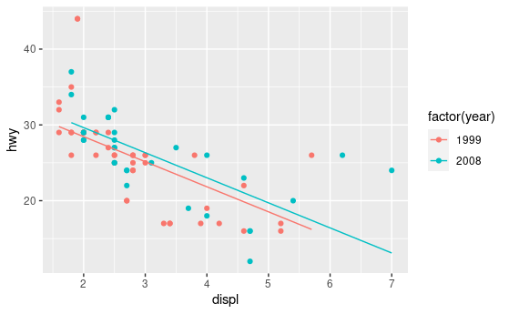

```r
data_space <- ggplot(data = mpg_manual, aes(x = displ, y = hwy, color = factor(year))) +
  geom_point()
data_space +
  geom_line(data = augment(mod), aes(y = .fitted, color = factor(year)))
```

**8. Let’s practice!**

Now it’s your turn to build some visualizations.

### **Using geom_line() and augment()**

Parallel slopes models are so-named because we can visualize these models in the data space as not one line, but two *parallel* lines. To do this, we’ll draw two things:

- a scatterplot showing the data, with color separating the points into groups
- a line for each value of the categorical variable

Our plotting strategy is to compute the fitted values, plot these, and connect the points to form a line. The `augment()` function from the `broom` package provides an easy way to add the fitted values to our data frame, and the `geom_line()` function can then use that data frame to plot the points and connect them.

Note that this approach has the added benefit of automatically coloring the lines appropriately to match the data.

You already know how to use `ggplot()` and `geom_point()` to make the scatterplot. The only twist is that now you’ll pass your `augment()`-ed model as the data argument in your `ggplot()` call. When you add your `geom_line()`, instead of letting the y aesthetic inherit its values from the `ggplot()` call, you can set it to the `.fitted` column of the `augment()`-ed model. This has the advantage of automatically coloring the lines for you.

**Instructions**

The parallel slopes model `mod` relating total price to the number of wheels and condition is already in your workspace.

- `augment()` the model `mod` and explore the returned data frame using `glimpse()`. Notice the new variables that have been created.
- Draw the scatterplot and save it as `data_space` by passing the `augment()`-ed model to `ggplot()` and using `geom_point()`. Use `geom_line()` *once* to add two parallel lines corresponding to our model.

```r
# Augment the model
augmented_mod <- augment(mod)
glimpse(augmented_mod)
```

```
Rows: 141
Columns: 9
$ totalPr    <dbl> 51.55, 37.04, 45.50, 44.00, 71.00,…
$ wheels     <int> 1, 1, 1, 1, 2, 0, 0, 2, 1, 1, 2, 2…
$ cond       <fct> new, used, new, new, new, new, use…
$ .fitted    <dbl> 49.60260, 44.01777, 49.60260, 49.6…
$ .resid     <dbl> 1.9473995, -6.9777674, -4.1026005,…
$ .hat       <dbl> 0.02103158, 0.01250410, 0.02103158…
$ .sigma     <dbl> 4.902339, 4.868399, 4.892414, 4.88…
$ .cooksd    <dbl> 1.161354e-03, 8.712334e-03, 5.1543…
$ .std.resid <dbl> 0.40270893, -1.43671086, -0.848389…
```

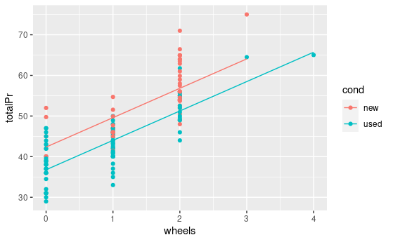

```r
# scatterplot, with color
data_space <- ggplot(data = augmented_mod, aes(x = wheels, y = totalPr, color = cond)) +
  geom_point()

# single call to geom_line()
data_space +
  geom_line(aes(y = .fitted))
```

Thinking geometrically is great way to get your head around how linear models work.

## **Interpreting parallel slopes coefficients**

**1. Interpreting parallel slopes coefficients**

**2. Intercept interpretation**

Most often, our primary interest in models like this one is interpreting the value of the coefficients. What does the model tell us about the relationship between fuel economy and engine size in the context of the year when the cars were manufactured? Let’s start with the main intercept. The value is 35.276 and the units are the same as those of the response variable—miles per gallon. Recall that this is the expected fuel economy for a car from 1999 that had an engine size of 0 liters. Of course, in this case, this value has little meaning, since there is no such thing as a car with an engine size of 0 liters, but that is the literal interpretation of the role that 35.276 plays in our model. As we saw above, the coefficient on year can also be thought of as an intercept. Note here that R has chosen to report the name of the coefficient as factor(year)2008. This reflects the fact that factor(year) was the name of the variable we gave R, and 2008 is the value of that variable that R is reporting about. This variable is identical to the newer variable that we defined in the previous set of slides. Here, R is telling us that cars manufactured in 2008 get about 1.4 miles per gallon better gas mileage than those manufactured in 1999, after controlling for engine size. This is our key finding, and I’ll return to this in just a minute.

```r
lm(hwy ~ displ + factor(year), data = mpg)
```

```
Call:
lm(formula = hwy ~ displ + factor(year), data = mpg)

Coefficients:
     (Intercept)             displ  factor(year)2008
          35.276            -3.611             1.402
```

**3. Slope interpretation**

How did we “control for engine size”? By including the displ variable in our model, we also obtain a coefficient for engine size. This is our slope coefficient, and it tells us that each extra liter of engine size is associated with a decrease in expected fuel economy of 3.61 miles per gallon, after controlling for year of manufacture. This is the negative relationship we saw earlier: larger engines tend to go in less fuel efficient cars. The difference now is that we are able to estimate the size of that effect while simultaneously considering the effect of time.

**4. Avoiding misunderstandings**

The interpretation of coefficients in a multiple regression model can get complicated, so let’s quickly review a few common mistakes. First, there is only one slope in the parallel slopes models that we can considered thus far. Yes, there are two explanatory variables, but only the one numeric explanatory variable is associated with a slope. Later, we will consider more complex models that have more than one “slope.” Second, pay careful attention to the reference level of your categorical variables. Every factor in R has a reference level - which you can set - but by default it is the first level alphabetically. Third, units are important. Every coefficient has units that relate to the units of the response variable. Intercepts are in the same units as the response variable, and slope coefficients are in the units of the response per unit of the explanatory variable. Finally, the key difference in multiple regression is that coefficients must be interpretted in the context of the other explanatory variables. The “after controlling for” phrasing is crucial to having a valid understanding of your model.

**5. Let’s practice!**

The next set of exercises will give you some practice interpretting coefficients.

## **Three ways to describe a model**

**1. Three ways to describe a model**

**2. Three ways to describe a model**

Regression models are abstract things, and as such we human beings have developed various ways of characterizing them. Models can be described by mathematical equations. In many cases, they can be visualized as geometric objects in two- or three-dimensions. And of course, they can be communicated to R via a suggestive syntax. Going forward, we will emphasize the connections between these three characterizations of models, and illustrate how an understanding of one can lead to a deeper understanding of another.

**3. Mathematical**

A multiple regression model can be expressed as an equation for the response variable y in terms of some explanatory variables x 1 and x 2. The coefficients of the model—beta 0, beta 1 , and beta 2—allow us to translate our knowledge about x into information about y. A statistical model will always include an error term like epsilon that captures our uncertainty. These errors—which are manifest as residuals—are critical to the process of statistical inference—but that is a subject for a later course. In this course, we will focus on the variables and the coefficients.

**4. Geometric**

Math isn’t everyone’s cup of tea, and while this doesn’t make it any less important, we will develop geometric intuition about regression models in this course. Our data live in a “space,” and we will refer to this as the “data space.” In this scatterplot, we view the highway gas mileage of several popular cars along with the corresponding size of their engines—as measured by displacement. Each point on the scatterplot represents an observation. A simple linear regression model can be visualized as a line through this data space.

**5. Syntactic**

Finally, R doesn’t really understand math or geometry. But of course, R is really good at performing the computations that we will need in order to fit and visualize our models. We will use a special syntax—called a formula—to communicate models to R. This syntax is less specific and more suggestive than a mathematical equation, but can be put into a 1-1 correspondence with it.

**6. Multiple regression**

As we extend simple linear regression into multiple regression, we will add additional explanatory variables. Instead of just having x, we will have x 1 and x 2, even possibly even more. The formula syntax will extend naturally, and additional coefficients will make their way into the mathematical equation. As we add complexity, the data space will increase from two to three—and even more—dimensions, and the class of geometric objects that we can use to describe models will broaden to include multiple lines, planes, and even multiple planes. Unfortunately, while the mathematical and syntactic characterizations will scale easily to an arbitrary number of explanatory variables, human beings are limited in our ability to visually process more than three numeric dimensions. We will get creative to push this boundary as far as we can, but we are doomed to fail.

**7. Let’s practice!**

Let’s practice our understanding in the next set of exercises.

### **Syntax from math**

The `babies` data set contains observations about the birthweight and other characteristics of children born in the San Francisco Bay area from 1960–1967.

We would like to build a model for birthweight as a function of the mother’s age and whether this child was her first (`parity == 0`). Use the mathematical specification below to code the model in R.

$$birthweight = \beta_{0} + \beta_{1}.age + \beta_{2}.parity + \epsilon$$
**Instructions**

The birthweight variable is recorded in the column `bwt`.

- Use lm() to build the parallel slopes model specified above. It’s not necessary to use `factor()` in this case as the variable `parity` is coded using binary numeric values.

```r
# build model
lm(bwt ~ age + parity, data = babies)
```

```
Call:
lm(formula = bwt ~ age + parity, data = babies)

Coefficients:
(Intercept)          age       parity
  118.27782      0.06315     -1.65248
```

### **Syntax from plot**

**Instructions**

```r
# build model
lm(bwt ~ gestation + smoke, data = babies)
```

```
Call:
lm(formula = bwt ~ gestation + smoke, data = babies)

Coefficients:
(Intercept)    gestation        smoke
    -0.9317       0.4429      -8.0883
```